# MS2_model

```r
extinct.raw <- read.csv("model_data2.csv")
extinct <- extinct.raw[,c("ma_range", "lat_range", "gcd", "svl", "mean_lat",
                 "min_lat", "abu_cat")]
extant <- read.csv("living_data2.csv")
extant <- extant[,-c(1,2)]
names(extant) <- c("species", "svl", "count", "abu_cat", "lat_range", "gcd", "mean_lat", "min_lat",
                                 "Red.List.status", "order", "family", "genus", "hab.cat.b")
```

# Data description

## Extant

```r
nrow(na.omit(extant))
```

```
## [1] 261
```

```r
summary(extant)
```

```
##                      species          svl              count
##  Lyciasalamandra luschani:   2   Min.   :  9.699   Min.   :   1.00
##  Salamandra algira       :   2   1st Qu.: 26.494   1st Qu.:   3.00
##  Salamandrina terdigitata:   2   Median : 37.504   Median :  13.00
##  Acanthixalus spinosus   :   1   Mean   : 46.469   Mean   : 110.11
##  Acris blanchardi        :   1   3rd Qu.: 56.000   3rd Qu.:  42.25
##  Acris crepitans         :   1   Max.   :927.994   Max.   :5037.00
##  (Other)                 :1959   NA's   :4         NA's   :1628
##     abu_cat       lat_range             gcd             mean_lat
##  Min.   :1.00   Min.   : 0.00201   Min.   :    0.0   Min.   :-44.261
##  1st Qu.:1.00   1st Qu.: 0.52441   1st Qu.:  111.3   1st Qu.:-12.451
##  Median :3.00   Median : 3.03725   Median :  446.4   Median :  2.367
##  Mean   :2.52   Mean   : 6.88834   Mean   : 1098.5   Mean   :  2.770
##  3rd Qu.:3.00   3rd Qu.: 9.83493   3rd Qu.: 1415.4   3rd Qu.: 14.338
##  Max.   :4.00   Max.   :86.89850   Max.   :20038.3   Max.   : 59.385
##  NA's   :565    NA's   :181        NA's   :181       NA's   :181
##     min_lat         Red.List.status     order               family
##  Min.   :-47.8074   LC     :817     ANURA  :1664   BUFONIDAE   :192
##  1st Qu.:-16.4686   EN     :257     CAUDATA:  85   MANTELLIDAE :170
##  Median : -1.3746   CR     :186     NA's   : 219   HYPEROLIIDAE:160
##  Mean   : -0.7894   VU     :182                    HYLIDAE     :141
##  3rd Qu.: 10.9962   DD     :169                    MICROHYLIDAE: 92
##  Max.   : 45.9292   (Other):138                    (Other)     :994
##  NA's   :181        NA's   :219                    NA's        :219
##                genus        hab.cat.b
##  Hyperolius       :  91   high   : 12
##  Eleutherodactylus:  75   highlow:880
##  Phrynobatrachus  :  66   low    :453
##  Atelopus         :  63   NA's   :623
##  Boophis          :  57
##  (Other)          :1397
##  NA's             : 219
```

```r
extant <- na.omit(extant)
extant <- droplevels(extant)
summary(extant)
```

```
##                   species         svl             count
##  Acris crepitans      :  1   Min.   : 12.90   Min.   :   1.00
##  Acris gryllus        :  1   1st Qu.: 30.50   1st Qu.:   4.00
##  Adenomera andreae    :  1   Median : 43.99   Median :  14.00
##  Afrixalus dorsalis   :  1   Mean   : 53.25   Mean   :  93.69
##  Afrixalus lacteus    :  1   3rd Qu.: 65.21   3rd Qu.:  42.00
##  Agalychnis callidryas:  1   Max.   :286.99   Max.   :5037.00
##  (Other)              :255
##     abu_cat        lat_range             gcd             mean_lat
##  Min.   :1.000   Min.   : 0.05339   Min.   :    0.0   Min.   :-35.839
##  1st Qu.:3.000   1st Qu.: 6.44265   1st Qu.:  995.1   1st Qu.:-12.412
##  Median :3.000   Median :13.49661   Median : 2183.4   Median :  2.069
##  Mean   :2.835   Mean   :17.35401   Mean   : 2731.8   Mean   :  2.168
##  3rd Qu.:3.000   3rd Qu.:24.45622   3rd Qu.: 3597.7   3rd Qu.:  9.819
##  Max.   :4.000   Max.   :86.89850   Max.   :20038.3   Max.   : 58.814
##
##     min_lat        Red.List.status   order                 family
##  Min.   :-43.703   CR:  4          ANURA:261   HYLIDAE        : 39
##  1st Qu.:-21.051   DD:  4                      MANTELLIDAE    : 38
##  Median : -8.568   EN:  8                      BUFONIDAE      : 25
##  Mean   : -6.929   EX:  1                      LEPTODACTYLIDAE: 20
##  3rd Qu.:  4.738   LC:224                      MICROHYLIDAE   : 17
##  Max.   : 40.415   NT:  9                      HYPEROLIIDAE   : 15
##                    VU: 11                      (Other)        :107
##              genus       hab.cat.b
##  Boophis        : 16   high   :  2
##  Phrynobatrachus: 14   highlow:146
##  Mantidactylus  : 13   low    :113
##  Leptodactylus  : 12
##  Hyperolius     :  9
##  Ptychadena     :  9
##  (Other)        :188
```

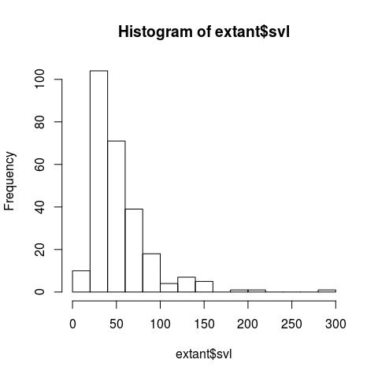

```r
hist(extant$svl)
```

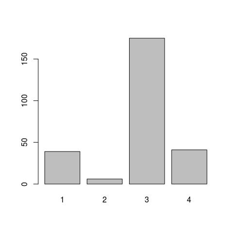

```r
barplot(table(extant$abu_cat))
```

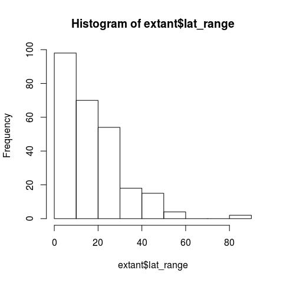

```r
hist(extant$lat_range)
```

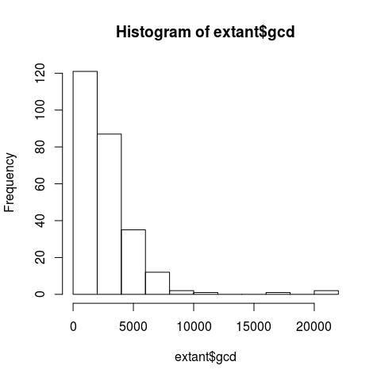

```r
hist(extant$gcd)
```

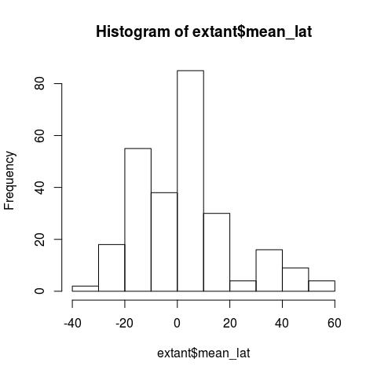

```r
hist(extant$mean_lat)
```

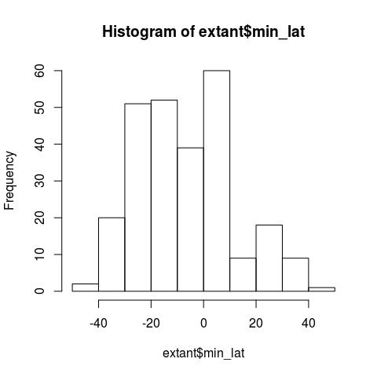

```r
hist(extant$min_lat)
```

261 complete cases in the data. Body size distribution as expected (follows a negative binomial, cut off at the lower end).

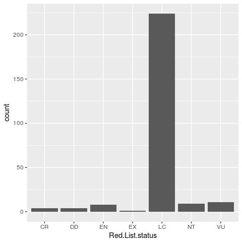

```r
ggplot(extant, aes(Red.List.status))+geom_bar()#+scale_y_log10()#+scale_y_continuous(limits = c(0,200), oob = squish)
```

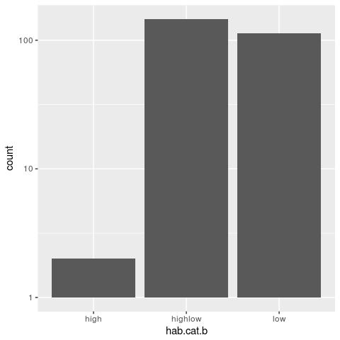

```r
ggplot(extant, aes(hab.cat.b))+geom_bar()+scale_y_log10()#limits = c(0,400), oob = squish)
```

Habitat distribution looks similar to extinct species. Only very few species from high energy habitats only.

## Comparability with fossil data

Data from the fossil record and from living species can differ greatly, but also share some common points. Data on geographic ranges, body size and habitat are comparable without further adjustments (?), whereas comparing data on abundance from extinct and living species would be most likely to the disadvantage of the extinct species, caused by the in general low preservation probability of terrestrial organisms. Another variable that is not comparable without further adjustments is extinction risk, wich is defined as species duration in the fossil record, but as category in the IUCN Red List. To bridge these differences between datasets, we chose to categorize data for abundance (mni_max and spec_max) and extinction risk (duration) for the extinct species data.

Applying the fossil data fitted model I will predict duration for extant species, which can be compared to their current assassment categories. Therefore, only abundance categorization has to be done. We regard EW and EX to be of the same results and therefore similar for our approach. DD species is not a category for extinction risk, therefore there is 6 categories for living species, which is in increasing order: LC, NT, VU, EN, CR, and EX.

# Modelling

## Data imputation

```r
extinct.imp <- extinct.raw[,c("ma_range", "lat_range", "gcd", "svl", "mean_lat",
                 "min_lat", "abu_cat")]
extinct.imp$abu_cat <- as.factor(extinct.imp$abu_cat) # set abundance as factor

imputation_rf_svl <- matrix(ncol=50, nrow=nrow(extinct.imp))
imputation_rf_abu <- matrix(ncol=50, nrow=nrow(extinct.imp))
for(i in 1:50){
  imputed <- rfImpute(extinct.imp, extinct$ma_range)
  imputation_rf_svl[,i] <- imputed$svl
  imputation_rf_abu[,i] <- imputed$abu_cat
}
```

[output not shown]

[output cut: 695 more lines]

[output not shown]

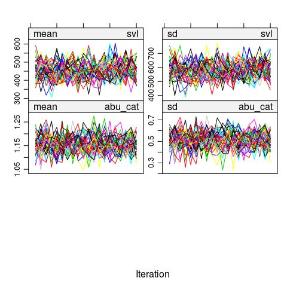

```r
# Using mice package
imputed <- mice(extinct.imp, maxit=20, m=50, print=FALSE, method = c("", "", "", "rf", "", "", "polr")) # polr
# use default imputation method for bodysize and polr instead of default polyreg (abu is an ordered factor)
plot(imputed, c("svl", "abu_cat")) # check convergence of the predictor algorithm
```

```r
# combine the multiple iterations into one mean imputed value
temp <- complete(imputed, action="broad", include=TRUE)
imputation_mice_svl <- temp[,grepl(pattern = "svl.[1-9]", x = names(temp))] # grab all imputed svl columns
imputation_mice_abu <- temp[,grepl(pattern = "abu_cat.[1-9]", x = names(temp))] # grab all imputed abu columns

# Impossible values?
table((imputation_rf_svl<=0))
```

```
##
## FALSE
## 17700
```

```r
table((imputation_mice_svl<=0))
```

```
##
## FALSE
## 17700
```

```
## Using  as id variables
```

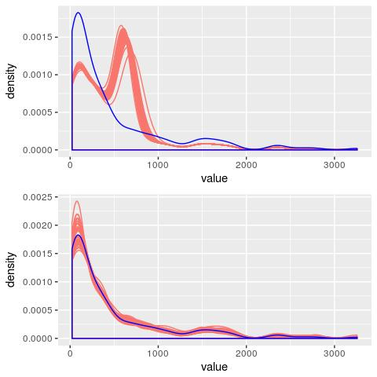

```r
# PLOTS
## plot densities to check if imputations are reasonable
grid.arrange(
ggplot(melt(imputation_rf_svl), aes(x=value))+
  geom_density(aes(group=X2, col="orange"), show.legend = FALSE)+
  geom_density(data=extinct.imp, aes(x=svl), col="blue"),
ggplot(melt(imputation_mice_svl), aes(x=value))+
  geom_density(aes(group=variable, col="orange"), show.legend = FALSE)+
  geom_density(data=extinct.imp, aes(x=svl), col="blue"))
```

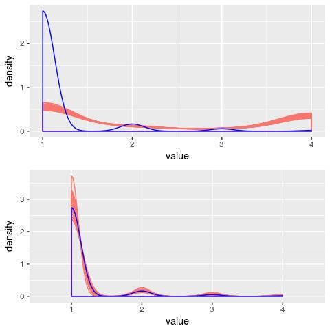

```r
grid.arrange(
ggplot(melt(imputation_rf_abu), aes(x=value))+
  geom_density(aes(group=X2, col="orange"), show.legend = FALSE)+
  geom_density(data=extinct.imp, aes(x=as.numeric(as.character(extinct.imp$abu_cat))), col="blue"),
ggplot(melt(as.matrix(imputation_mice_abu)), aes(x=value))+
  geom_density(aes(group=X2, col="orange"), show.legend = FALSE)+
  geom_density(data=extinct.imp, aes(x=as.numeric(as.character(extinct.imp$abu_cat))), col="blue"))
```

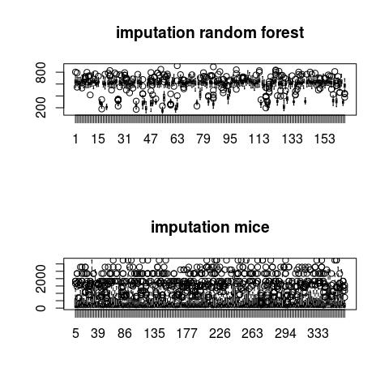

```r
## Mean imputated values
par(mfrow=c(2,1))
which_svl_imp <- as.numeric(row.names(imputed$imp$svl))
boxplot(t(imputation_rf_svl[which_svl_imp,]), main="imputation random forest")
boxplot(t(imputation_mice_svl[which_svl_imp,]), main="imputation mice")
```

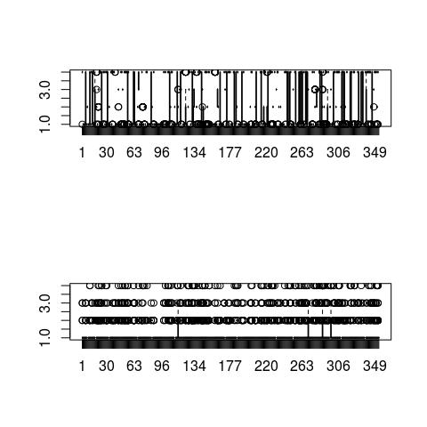

```r
# ignore the numbering, first plot reasigns the row numbers, second keeps the old ones

imputation_mice_abu <- apply(imputation_mice_abu, 2, function(x) as.numeric(as.character(x)))
boxplot(t(imputation_rf_abu)); boxplot(t(imputation_mice_abu))
```

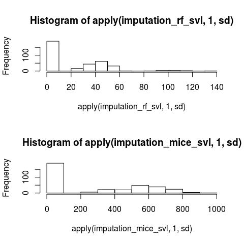

```r
# check for sd of the imputed data. values==0 are the not imputed data
#imputation_rf_abu <- apply(imputation_rf_abu, 2, function(x) as.numeric(as.character(x)))
hist(apply(imputation_rf_svl, 1, sd)); hist(apply(imputation_mice_svl, 1, sd))
```

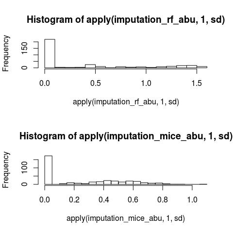

```r
hist(apply(imputation_rf_abu, 1, sd), breaks=20); hist(apply(imputation_mice_abu, 1, sd), breaks=20)
```

```r
psych::describe(apply(imputation_rf_abu, 1, sd), IQR=TRUE)
```

```
##    vars   n mean   sd median trimmed mad min  max range skew kurtosis   se
## X1    1 354 0.36 0.54      0    0.27   0   0 1.52  1.52 1.11    -0.39 0.03
##     IQR
## X1 0.65
```

```r
psych::describe(apply(imputation_mice_abu, 1, sd), IQR=TRUE)
```

```
##    vars   n mean   sd median trimmed  mad min  max range skew kurtosis
## X1    1 354 0.25 0.27   0.17    0.22 0.25   0 1.07  1.07 0.52    -1.13
##      se  IQR
## X1 0.01 0.48
```

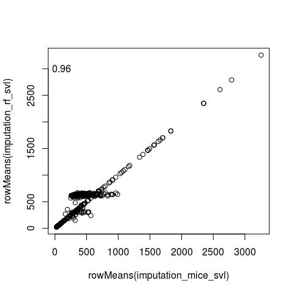

```r
par(mfrow=c(1,1))
plot(rowMeans(imputation_mice_svl), rowMeans(imputation_rf_svl), alpha=0.5)
text(100, 3000, round(cor(rowMeans(imputation_mice_svl), rowMeans(imputation_rf_svl)),2))
```

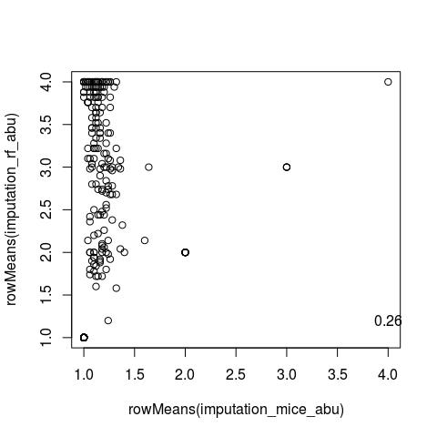

```r
plot(rowMeans(imputation_mice_abu), rowMeans(imputation_rf_abu))
text(4, 1.2, round(cor(rowMeans(imputation_mice_abu), rowMeans(imputation_rf_abu)),2))
```

```r
# Add the imputed data
extinct.imp$svl <- rowMeans(imputation_mice_svl)

extinct.imp$abu_cat  <- as.factor(apply(imputation_mice_abu, 1,
                                        function(x) names(sort(table(x), decreasing = TRUE))[1]))

extinct.imp <- cbind(extinct.imp, extinct.raw[,c("species", "order", "family", "genus", "complete_case")])
imp <- extinct.imp[,c("ma_range", "lat_range", "gcd", "svl", "mean_lat",
                 "min_lat", "abu_cat")]
```

### Analyze data imputation

```r
svl_imputed <- extinct$svl==extinct.imp$svl
svl_imputed <- !is.na(svl_imputed)
abu_cat_imputed <- extinct$abu_cat==extinct.imp$abu_cat
abu_cat_imputed <- !is.na(abu_cat_imputed)
extinct.imp <- cbind(extinct.imp, svl_imputed, abu_cat_imputed)

round(tapply(extinct.imp$svl_imputed, extinct.raw$order, sum)/
        tapply(extinct.imp$svl_imputed, extinct.raw$order, length),2)
```

```
##   Allocaudata  Lepospondyli Parabatrachia     Salientia Temnospondyli
##          0.91          0.67          0.00          0.39          0.57
##       Urodela
##          0.54
```

```r
round(tapply(extinct.imp$abu_cat_imputed, extinct.raw$order, sum)/
        tapply(extinct.imp$abu_cat_imputed, extinct.raw$order, length),2)
```

```
##   Allocaudata  Lepospondyli Parabatrachia     Salientia Temnospondyli
##          0.82          0.64          0.00          0.36          0.47
##       Urodela
##          0.51
```

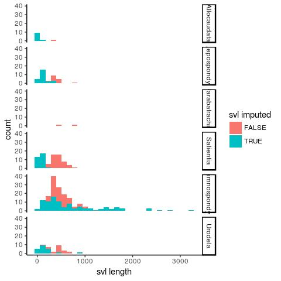

```r
ggplot(extinct.imp[is.na(extinct.imp$order)==FALSE,], aes(svl, fill=svl_imputed))+
  geom_histogram()+
  scale_fill_hue("svl imputed")+
  xlab("svl length")+
  theme_classic()+
  facet_grid(order ~ .)
```

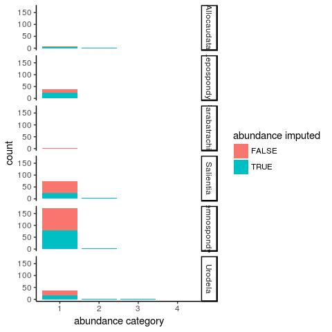

```r
ggplot(extinct.imp[is.na(extinct.imp$order)==FALSE,], aes(abu_cat, fill=abu_cat_imputed))+
  geom_bar()+
  scale_fill_hue("abundance imputed")+
  xlab("abundance category")+
  theme_classic()+
  facet_grid(order ~ .)
```

Data imputed is only data on abundance and body size.

## Distribution check

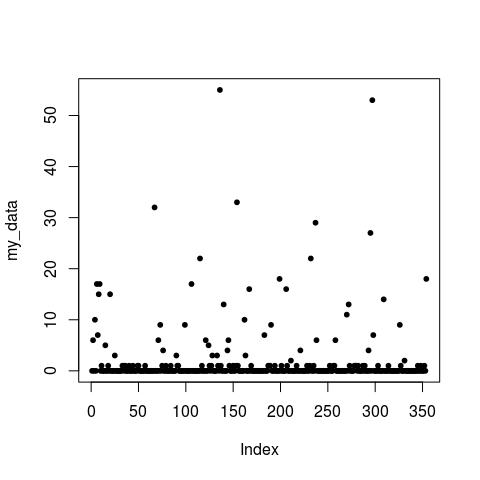

```r
my_data <- extinct$ma_range
plot(my_data, pch=20)
```

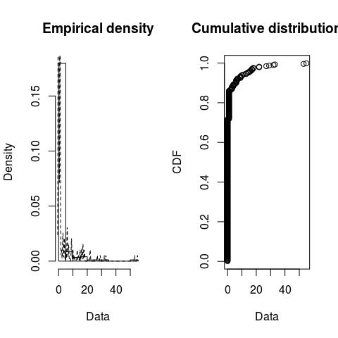

```r
plotdist(my_data, histo=TRUE, demp=TRUE)
```

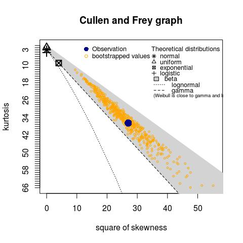

```
## summary statistics
## ------
## min:  0   max:  55
## median:  0
## mean:  1.926554
## estimated sd:  6.163056
## estimated skewness:  5.197434
## estimated kurtosis:  36.43398
```

```r
descdist(my_data, discrete=FALSE, boot=500)
```

According to fitdistrplus::descdist the response variable shows a beta distribution.

## Generalized additive model

GAM was fitted to the data to allow for non-linear relationships between the predictor variables and the species duration. Normality (qq plot) and homogeneity are violated (residuals vs. fitted values (linear predictor)).

Zuur on chosing a smoother: “In practise, the difference between cubic regression splines, thin plate regression splines, B-splines, P-splines, etc., is rather small”.

```r
# logging the skewed variables
imp2 <- log(imp[,c("ma_range", "lat_range", "gcd", "svl")]+1)
imp2$mean_lat <- imp$mean_lat; imp2$min_lat <- imp$min_lat; imp2$abu_cat <- imp$abu_cat;
extinct2 <- log(extinct[,c("ma_range", "lat_range", "gcd", "svl")]+1)
extinct2$mean_lat <- extinct$mean_lat; extinct2$min_lat <- extinct$min_lat; extinct2$abu_cat <- extinct$abu_cat;

gam.incomp <- gam(data=extinct, ma_range ~ s(lat_range) + s(gcd) + s(svl) + s(mean_lat) +
                  s(min_lat) + s(as.numeric(as.character(abu_cat)), k=4))
gam.incomp.log <- gam(data=extinct2, ma_range ~ s(lat_range) + s(gcd) + s(svl) + s(mean_lat) +
                  s(min_lat) + s(as.numeric(as.character(abu_cat)), k=4))
gam.imp <- gam(data=imp, ma_range ~ s(lat_range) + s(gcd) + s(svl) + s(mean_lat) +
                s(min_lat) + s(as.numeric(as.character(abu_cat)), k=4))
gam.imp.log <- gam(data=imp2, ma_range ~ s(lat_range) + s(gcd) + s(svl) + s(mean_lat) +
                s(min_lat) + s(as.numeric(as.character(abu_cat)), k=4))

summary(gam.incomp)
```

```
##
## Family: gaussian
## Link function: identity
##
## Formula:
## ma_range ~ s(lat_range) + s(gcd) + s(svl) + s(mean_lat) + s(min_lat) +
##     s(as.numeric(as.character(abu_cat)), k = 4)
##
## Parametric coefficients:
##             Estimate Std. Error t value Pr(>|t|)
## (Intercept)   2.7818     0.4963   5.605 9.12e-08 ***
## ---
## Signif. codes:  0 '***' 0.001 '**' 0.01 '*' 0.05 '.' 0.1 ' ' 1
##
## Approximate significance of smooth terms:
##                                        edf Ref.df      F  p-value
## s(lat_range)                         1.000  1.000  0.231 0.631536
## s(gcd)                               1.689  2.095  0.728 0.515516
## s(svl)                               1.000  1.000  0.172 0.679293
## s(mean_lat)                          1.000  1.000 14.832 0.000169 ***
## s(min_lat)                           1.000  1.000 13.971 0.000257 ***
## s(as.numeric(as.character(abu_cat))) 1.000  1.000  0.092 0.761784
## ---
## Signif. codes:  0 '***' 0.001 '**' 0.01 '*' 0.05 '.' 0.1 ' ' 1
##
## R-sq.(adj) =    0.2   Deviance explained = 23.3%
## GCV = 42.631  Scale est. = 40.645    n = 165
```

```r
summary(gam.incomp.log)
```

```
##
## Family: gaussian
## Link function: identity
##
## Formula:
## ma_range ~ s(lat_range) + s(gcd) + s(svl) + s(mean_lat) + s(min_lat) +
##     s(as.numeric(as.character(abu_cat)), k = 4)
##
## Parametric coefficients:
##             Estimate Std. Error t value Pr(>|t|)
## (Intercept)  0.58956    0.06206   9.499   <2e-16 ***
## ---
## Signif. codes:  0 '***' 0.001 '**' 0.01 '*' 0.05 '.' 0.1 ' ' 1
##
## Approximate significance of smooth terms:
##                                        edf Ref.df      F  p-value
## s(lat_range)                         3.328  4.056  0.672 0.631941
## s(gcd)                               5.547  6.638  2.491 0.017673 *
## s(svl)                               1.000  1.000  0.129 0.720418
## s(mean_lat)                          1.000  1.000 14.204 0.000232 ***
## s(min_lat)                           1.000  1.000 13.458 0.000335 ***
## s(as.numeric(as.character(abu_cat))) 1.000  1.000  0.001 0.972482
## ---
## Signif. codes:  0 '***' 0.001 '**' 0.01 '*' 0.05 '.' 0.1 ' ' 1
##
## R-sq.(adj) =  0.355   Deviance explained = 40.6%
## GCV = 0.69391  Scale est. = 0.63556   n = 165
```

```r
summary(gam.imp)
```

```
##
## Family: gaussian
## Link function: identity
##
## Formula:
## ma_range ~ s(lat_range) + s(gcd) + s(svl) + s(mean_lat) + s(min_lat) +
##     s(as.numeric(as.character(abu_cat)), k = 4)
##
## Parametric coefficients:
##             Estimate Std. Error t value Pr(>|t|)
## (Intercept)   1.9266     0.2508   7.682 1.81e-13 ***
## ---
## Signif. codes:  0 '***' 0.001 '**' 0.01 '*' 0.05 '.' 0.1 ' ' 1
##
## Approximate significance of smooth terms:
##                                        edf Ref.df      F  p-value
## s(lat_range)                         9.000  9.000  8.090 5.51e-11 ***
## s(gcd)                               8.890  8.994 10.054 6.20e-14 ***
## s(svl)                               1.573  1.956  0.818    0.486
## s(mean_lat)                          1.000  1.000 48.053 1.94e-11 ***
## s(min_lat)                           1.000  1.000 47.074 3.02e-11 ***
## s(as.numeric(as.character(abu_cat))) 2.326  2.655  2.425    0.150
## ---
## Signif. codes:  0 '***' 0.001 '**' 0.01 '*' 0.05 '.' 0.1 ' ' 1
##
## R-sq.(adj) =  0.414   Deviance explained = 45.3%
## GCV =  23.94  Scale est. = 22.263    n = 354
```

```r
summary(gam.imp.log)
```

```
##
## Family: gaussian
## Link function: identity
##
## Formula:
## ma_range ~ s(lat_range) + s(gcd) + s(svl) + s(mean_lat) + s(min_lat) +
##     s(as.numeric(as.character(abu_cat)), k = 4)
##
## Parametric coefficients:
##             Estimate Std. Error t value Pr(>|t|)
## (Intercept)  0.42572    0.03575   11.91   <2e-16 ***
## ---
## Signif. codes:  0 '***' 0.001 '**' 0.01 '*' 0.05 '.' 0.1 ' ' 1
##
## Approximate significance of smooth terms:
##                                        edf Ref.df      F  p-value
## s(lat_range)                         4.177  5.072  1.591    0.164
## s(gcd)                               7.412  8.370  7.000 8.49e-09 ***
## s(svl)                               4.336  5.365  1.752    0.104
## s(mean_lat)                          1.000  1.000 24.028 1.46e-06 ***
## s(min_lat)                           1.000  1.000 22.839 2.61e-06 ***
## s(as.numeric(as.character(abu_cat))) 1.000  1.000  0.029    0.864
## ---
## Signif. codes:  0 '***' 0.001 '**' 0.01 '*' 0.05 '.' 0.1 ' ' 1
##
## R-sq.(adj) =  0.381   Deviance explained = 41.4%
## GCV = 0.4794  Scale est. = 0.45241   n = 354
```

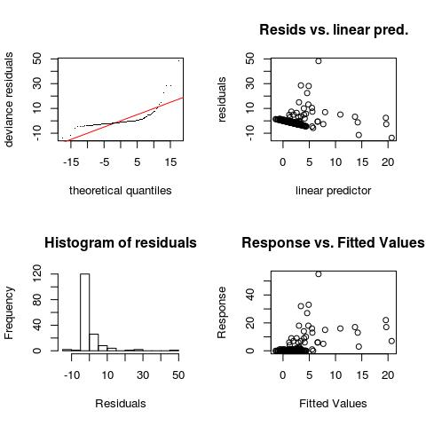

```
##
## Method: GCV   Optimizer: magic
## Smoothing parameter selection converged after 18 iterations.
## The RMS GCV score gradient at convergence was 6.749388e-07 .
## The Hessian was positive definite.
## Model rank =  49 / 49
##
## Basis dimension (k) checking results. Low p-value (k-index<1) may
## indicate that k is too low, especially if edf is close to k'.
##
##                                        k'  edf k-index p-value
## s(lat_range)                         9.00 1.00    1.07    0.84
## s(gcd)                               9.00 1.69    1.03    0.56
## s(svl)                               9.00 1.00    1.08    0.88
## s(mean_lat)                          9.00 1.00    1.00    0.33
## s(min_lat)                           9.00 1.00    1.09    0.93
## s(as.numeric(as.character(abu_cat))) 3.00 1.00    1.07    0.81
```

```r
par(mfrow=c(2,2))
gam.check(gam.incomp)
```

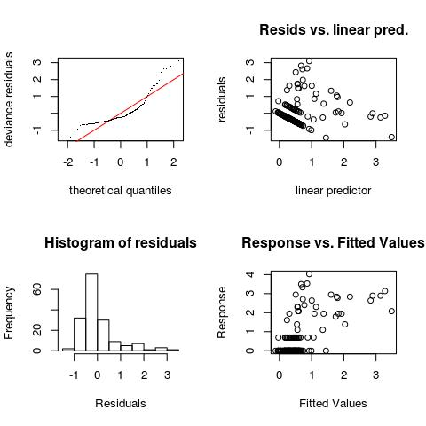

```
##
## Method: GCV   Optimizer: magic
## Smoothing parameter selection converged after 16 iterations.
## The RMS GCV score gradient at convergence was 2.973255e-08 .
## The Hessian was positive definite.
## Model rank =  49 / 49
##
## Basis dimension (k) checking results. Low p-value (k-index<1) may
## indicate that k is too low, especially if edf is close to k'.
##
##                                        k'  edf k-index p-value
## s(lat_range)                         9.00 3.33    1.13    0.96
## s(gcd)                               9.00 5.55    1.01    0.47
## s(svl)                               9.00 1.00    1.08    0.85
## s(mean_lat)                          9.00 1.00    1.00    0.37
## s(min_lat)                           9.00 1.00    1.06    0.71
## s(as.numeric(as.character(abu_cat))) 3.00 1.00    0.97    0.32
```

```r
gam.check(gam.incomp.log)
```

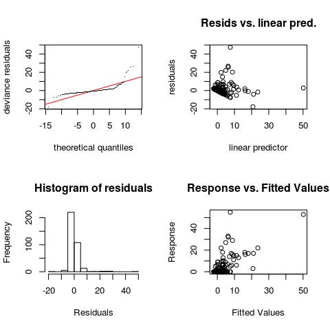

```
##
## Method: GCV   Optimizer: magic
## Smoothing parameter selection converged after 28 iterations.
## The RMS GCV score gradient at convergence was 5.401205e-07 .
## The Hessian was positive definite.
## Model rank =  49 / 49
##
## Basis dimension (k) checking results. Low p-value (k-index<1) may
## indicate that k is too low, especially if edf is close to k'.
##
##                                        k'  edf k-index p-value
## s(lat_range)                         9.00 9.00    1.00    0.39
## s(gcd)                               9.00 8.89    1.02    0.64
## s(svl)                               9.00 1.57    1.06    0.92
## s(mean_lat)                          9.00 1.00    1.03    0.70
## s(min_lat)                           9.00 1.00    0.99    0.28
## s(as.numeric(as.character(abu_cat))) 3.00 2.33    1.00    0.47
```

```r
gam.check(gam.imp)
```

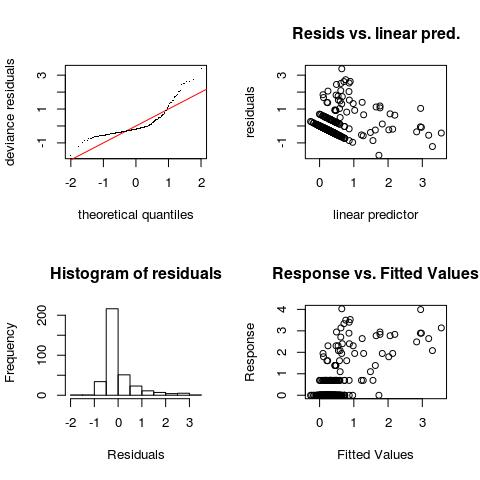

```
##
## Method: GCV   Optimizer: magic
## Smoothing parameter selection converged after 17 iterations.
## The RMS GCV score gradient at convergence was 6.093325e-08 .
## The Hessian was positive definite.
## Model rank =  49 / 49
##
## Basis dimension (k) checking results. Low p-value (k-index<1) may
## indicate that k is too low, especially if edf is close to k'.
##
##                                        k'  edf k-index p-value
## s(lat_range)                         9.00 4.18    1.00    0.46
## s(gcd)                               9.00 7.41    0.97    0.27
## s(svl)                               9.00 4.34    1.02    0.58
## s(mean_lat)                          9.00 1.00    1.04    0.72
## s(min_lat)                           9.00 1.00    0.92    0.07 .
## s(as.numeric(as.character(abu_cat))) 3.00 1.00    0.96    0.19
## ---
## Signif. codes:  0 '***' 0.001 '**' 0.01 '*' 0.05 '.' 0.1 ' ' 1
```

```r
gam.check(gam.imp.log)
```

```r
par(mfrow=c(1,1))

# Chose model gam.imp. Adjust family?
gam.imp <- gam(data=imp, ma_range ~ s(lat_range) + s(gcd) + s(svl) + s(mean_lat) +
                s(min_lat) + s(as.numeric(as.character(abu_cat)), k=4), method="REML")
gam.imp.new <- gam(data=imp, ma_range ~ s(lat_range) + s(gcd) + s(svl) + s(mean_lat) +
                s(min_lat) + s(as.numeric(as.character(abu_cat)), k=4),
               family = nb())
summary(gam.imp.new)
```

```
##
## Family: Negative Binomial(0.205)
## Link function: log
##
## Formula:
## ma_range ~ s(lat_range) + s(gcd) + s(svl) + s(mean_lat) + s(min_lat) +
##     s(as.numeric(as.character(abu_cat)), k = 4)
##
## Parametric coefficients:
##             Estimate Std. Error z value Pr(>|z|)
## (Intercept)  -0.2979     0.1421  -2.097    0.036 *
## ---
## Signif. codes:  0 '***' 0.001 '**' 0.01 '*' 0.05 '.' 0.1 ' ' 1
##
## Approximate significance of smooth terms:
##                                        edf Ref.df Chi.sq  p-value
## s(lat_range)                         1.000  1.000  1.216   0.2701
## s(gcd)                               3.064  3.651 49.063 8.35e-10 ***
## s(svl)                               2.703  3.368  7.442   0.0795 .
## s(mean_lat)                          1.600  1.981 44.041 2.74e-10 ***
## s(min_lat)                           1.002  1.003 42.172 8.66e-11 ***
## s(as.numeric(as.character(abu_cat))) 1.862  2.163  2.288   0.3488
## ---
## Signif. codes:  0 '***' 0.001 '**' 0.01 '*' 0.05 '.' 0.1 ' ' 1
##
## R-sq.(adj) =  -2.1e+06   Deviance explained = 79.1%
## -REML = 432.11  Scale est. = 1         n = 354
```

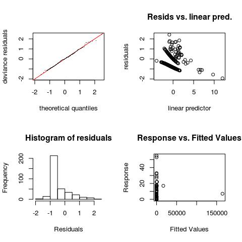

```
##
## Method: REML   Optimizer: outer newton
## full convergence after 11 iterations.
## Gradient range [-0.0004003171,2.627854e-05]
## (score 432.1067 & scale 1).
## Hessian positive definite, eigenvalue range [9.1961e-06,45.14962].
## Model rank =  49 / 49
##
## Basis dimension (k) checking results. Low p-value (k-index<1) may
## indicate that k is too low, especially if edf is close to k'.
##
##                                        k'  edf k-index p-value
## s(lat_range)                         9.00 1.00    0.71    0.40
## s(gcd)                               9.00 3.06    0.68    0.13
## s(svl)                               9.00 2.70    0.72    0.46
## s(mean_lat)                          9.00 1.60    0.70    0.32
## s(min_lat)                           9.00 1.00    0.67    0.12
## s(as.numeric(as.character(abu_cat))) 3.00 1.86    0.73    0.59
```

```r
par(mfrow=c(2,2))
gam.check(gam.imp.new)
```

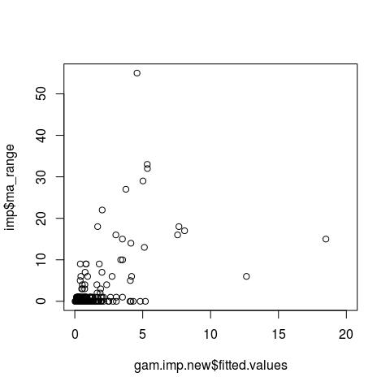

```r
par(mfrow=c(1,1))
plot(imp$ma_range~gam.imp.new$fitted.values, xlim=c(0,20))
```

```r
# Choose standard family, as negative binomial looks overfitted (very high deviance explained), has huuuge outliers.
# The r squared value points, despite the better AIC and deviance, to a fitting problem
final.gam <- gam.imp

# Predict
predict.gam <- predict.gam(gam.imp, newdata = extant)
range(predict.gam) # there is lots of negative predictions in the gam; adjust:
```

```
## [1] -89.6096  25.3663
```

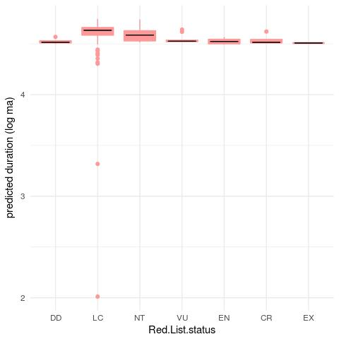

```r
predict.gam <- predict.gam+abs(min(predict.gam))

res <- extant
res$Red.List.status <- ordered(res$Red.List.status, levels = c("DD", "LC", "NT", "VU", "EN", "CR", "EW", "EX"))
res$predict.gam <- predict.gam

library(ggthemes)
theme=theme_set(theme_minimal())

(gam.fin <- ggplot(res, aes(x=Red.List.status, y=log(predict.gam)))+
    geom_boxplot(outlier.colour=NULL, colour="#FF9999", fill="#FF9999")+
    scale_y_continuous("predicted duration (log ma)")+
    stat_summary(geom = "crossbar",
                 width=0.65, fatten=.5,
                 color="black",
                 fun.data = function(x){return(c(y=median(x), ymin=median(x), ymax=median(x)))})
)
```

```r
library(reshape)
res2 <- melt(res[,c("Red.List.status", "predict.gam")])
kruskal.test(res$predict.gam, res$Red.List.status)
```

```
##
##  Kruskal-Wallis rank sum test
##
## data:  res$predict.gam and res$Red.List.status
## Kruskal-Wallis chi-squared = 43.754, df = 6, p-value = 8.271e-08
```

```r
pairwise.wilcox.test(res$predict.gam, res$Red.List.status, p.adjust.method = "fdr")
```

```
##
##  Pairwise comparisons using Wilcoxon rank sum test
##
## data:  res$predict.gam and res$Red.List.status
##
##    DD     LC     NT     VU     EN     CR
## LC 0.0390 -      -      -      -      -
## NT 0.3189 0.2849 -      -      -      -
## VU 0.3385 0.0019 0.3915 -      -      -
## EN 0.9800 0.0019 0.1510 0.5250 -      -
## CR 1.0000 0.0717 0.3385 0.3645 0.9428 -
## EX 0.9428 0.3295 0.3500 0.3385 0.9800 0.5250
##
## P value adjustment method: fdr
```